#MERGE TOTAL

#MERGE DE GOBERNANZA

```r
#VARIABLE 1 - ACCOUNTABILITY

library(rio)
lXLSX="https://github.com/IvonneMM/COVID19grupo2oficial/raw/master/Data_From_Worldwide_Governance_Indicators_Voice%20and%20Accountability%20Percentile%20Rank.xlsx"

VoiceandAcc=import(lXLSX)

VoiceandAcc[,c(2,3,4)]=NULL

VoiceandAcc$`2018 [YR2018]`=as.numeric(VoiceandAcc$`2018 [YR2018]`)
table(VoiceandAcc$`2018 [YR2018]`,useNA = "always")
```

```
##
## 0.9852217  4.926108  6.403941  7.881773  9.852217  10.34483  11.82266  15.76355
##         1         1         1         1         1         1         1         1
##  18.71921  19.21182  25.12315  26.60098  31.52709  33.99015  35.46798  37.43842
##         1         1         1         1         1         1         1         1
##  39.90148  40.39409   40.8867  44.33498  44.82759   45.3202  45.81281  46.30542
##         1         1         1         1         1         1         1         1
##  47.29064  48.27586  49.26109   50.2463  51.23153  52.70936  53.20197  55.17241
##         1         1         1         1         1         1         1         1
##  56.15763  56.65025  58.12808  58.62069   59.1133  60.59113  61.08374  61.57635
##         1         1         1         1         1         1         1         1
##  64.03941  64.53202  65.51724  66.99507  67.48769  68.47291  68.96552  69.45813
##         2         1         1         1         1         1         1         1
##  71.42857  71.92118  73.39902  74.38424  74.87685  75.36946  75.86207  76.35468
##         1         1         1         1         1         1         1         1
##  76.84729   77.3399  77.83251  78.32513  79.31035  80.78818  81.28078   81.7734
##         1         1         1         1         1         1         1         1
##  82.26601  82.75862  83.25123  84.23645  84.72906  87.68473  88.17734  88.66995
##         1         1         1         1         1         1         1         1
##  89.16256  89.65517  91.62562  92.11823  92.61084  93.10345  93.59606  94.08867
##         1         1         4         1         1         1         1         1
##  94.58128  95.07389  96.05911  96.55173  97.04433  97.53695  98.02956  98.52217
##         1         1         1         1         1         1         1         1
##  99.01478       100      <NA>
##         1         1         5
```

```r
names(VoiceandAcc)=c("Pais","VoiceandAccountability")

library(rio)
lkXLSX = "https://github.com/IvonneMM/COVID19grupo2oficial/raw/master/America%20y%20Europa3%20(3)%20(1)%20(1).xls"
Paisesoficial=import(lkXLSX)

VoiceandAccountability = merge(VoiceandAcc,Paisesoficial,by.x='Pais',by.y='Pais')
```

```r
# VARIABLE 2 - CORRUPCION Y VIOLENCIA

library(rio)
lkcorrup='https://github.com/GonzaloBerger/123/raw/master/Data_Extract_From_Worldwide_Governance_control_of_corruption.xlsx'

datacorrup=import(lkcorrup)

datacorrup[c(2:4)]=NULL

datacorrup=datacorrup[c(1:99),]

names(datacorrup)=c('Pais','Control de la corrupción')

datacorrup$`Control de la corrupción`=as.numeric(datacorrup$`Control de la corrupción`)
lkviolence='https://github.com/GonzaloBerger/123/raw/master/Data_Extract_From_Worldwide_Governance_Indicators_political_stability_and_absence_of_violence.xlsx'

dataviolence=import(lkviolence)

dataviolence[c(2:4)]=NULL

dataviolence=dataviolence[c(1:99),]

names(dataviolence)=c('Pais','Estabilidad política y ausencia de violencia/terrorismo')

dataviolence$`Estabilidad política y ausencia de violencia/terrorismo`=as.numeric(dataviolence$`Estabilidad política y ausencia de violencia/terrorismo`)
corrupcion_y_violencia=merge(datacorrup,dataviolence)

lkpaises='https://github.com/IvonneMM/COVID19grupo2oficial/raw/master/America%20y%20Europa3%20(3)%20(1)%20(1).xls'

datapaises=import(lkpaises)

Corrupcion_y_violencia=merge(datapaises,corrupcion_y_violencia)
```

```r
#VARIABLE 3 - EFECTIVIDAD DEL GOBIERNO

library(rio)

Gobernabilidad="https://github.com/IvonneMM/COVID19grupo2oficial/raw/master/Data_Extract_From_Worldwide_Governance_Indicators%20(2)%20(1).xls"
Gobernabilidad=import(Gobernabilidad)

names(Gobernabilidad)= c ("Pais", "Gobernabilidad")

Gobernabilidad$Gobernabilidad=as.numeric(Gobernabilidad$Gobernabilidad)
#VARIABLE 4 - IMPERIO DE LA LEY

library(rio)

lkXLSX= "https://github.com/IvonneMM/COVID19grupo2oficial/raw/master/Data_From_Worldwide_Governance_Indicators_Rule%20of%20Law%20Percentile%20Rank.xlsx"

RuleofLaw= import(lkXLSX)

RuleofLaw[,c(2,3,4)] = NULL

RuleofLaw$`2018 [YR2018]`=as.numeric(RuleofLaw$`2018 [YR2018]`)
table(RuleofLaw$`2018 [YR2018]`,useNA = "always")
```

```
##
##        0     6.25 7.692307 9.615385 12.98077 13.46154 14.90385 15.86539
##        1        1        1        1        1        1        1        1
## 16.34615 17.78846 19.23077 19.71154 20.19231 20.67308 24.03846 27.40385
##        1        1        1        1        1        1        1        1
## 28.84615 29.32692 32.21154 32.69231 35.09615 35.57692 37.01923 38.46154
##        1        1        1        1        1        1        1        1
## 38.94231 39.42308 40.38462 41.82692 42.30769    43.75 44.23077 45.67308
##        1        1        1        1        1        1        1        1
## 46.15385 46.63462 48.55769 49.03846 50.48077 51.44231 51.92308 52.40385
##        1        1        1        1        1        1        1        1
## 53.36538 57.21154 57.69231 59.13462 61.53846     62.5 62.98077 63.46154
##        1        1        1        1        1        1        1        1
## 63.94231 65.38461 65.86539 66.82692 67.30769 69.23077 70.19231 71.15385
##        1        1        1        1        1        1        1        1
## 72.11539 72.59615 73.07692 73.55769 74.03846 75.96154 76.44231 78.84615
##        1        1        1        1        1        1        1        2
## 79.32692 79.80769 80.28846 81.73077 82.69231 83.65385 84.61539 85.09615
##        1        1        1        1        1        1        1        1
## 85.57692 86.53846 87.01923 88.46154 88.94231 89.42308 89.90385 90.86539
##        1        1        1        1        1        1        1        1
## 91.34615 91.82692 92.30769 93.26923 94.23077 94.71154 95.67308 96.15385
##        1        1        1        1        2        1        1        1
## 96.63461 97.59615 98.55769 99.03846 99.51923      100     <NA>
##        1        1        1        1        1        1        3
```

```r
names(RuleofLaw)=c("Pais","RuleofLaw")

lkXLSX = "https://github.com/IvonneMM/COVID19grupo2oficial/raw/master/America%20y%20Europa3%20(3)%20(1)%20(1).xls"

Paisesoficial=import(lkXLSX)

ImperiodelaLey=merge(RuleofLaw,Paisesoficial,by.x='Pais', by.y='Pais')
```

```r
#MERGE 1 - de variable 1 y 2

Accountability_Corrupcion_y_violencia=merge(VoiceandAccountability,Corrupcion_y_violencia)
```

```r
#MERGE 2  - variable 3 y 4

Gob_Ley=merge(Gobernabilidad,ImperiodelaLey)
```

```r
#MERGE DE LA VARIABLE GOBERNANZA - VARIABLES 1, 2, 3 Y 4

Gobernanza=merge(Accountability_Corrupcion_y_violencia,Gob_Ley)
```

#MERGE DE SALUD

LIMPIEZA DE LA BASE DE DATOS DE GASTO ACTUAL EN SALUD (Current Health Expenditure - CHE)

1. Trayendo la base de datos:

```r
library(htmltab)

linkCIA_che = "https://www.cia.gov/library/publications/resources/the-world-factbook/fields/409.html"
linkPath_che='//*[@id="fieldListing"]'

che= htmltab(doc = linkCIA_che,
             which = linkPath_che)
```

```
## No encoding supplied: defaulting to UTF-8.
```

2. Separando columnas

```r
library(tidyr)

che=separate(che,`Current Health Expenditure`,into = c("oficial","delete"),"%")
```

3.Eliminando columnas que no necesitamos

```r
che$delete=NULL
```

4. Cambiando nombres

```r
names(che)=c("Pais","CHE")
```

5.Ver tabla

```r
str(che)
```

```
## 'data.frame':    193 obs. of  2 variables:
##  $ Pais: chr  "Afghanistan" "Albania" "Algeria" "Andorra" ...
##  $ CHE : chr  "11.8" "6.7" "6.4" "10.3" ...
```

6. Cambiar chr a numérico

```r
che$CHE=as.numeric(che$CHE)
```

7. Volvemos a visualizar la tabla

```r
str(che)
```

```
## 'data.frame':    193 obs. of  2 variables:
##  $ Pais: chr  "Afghanistan" "Albania" "Algeria" "Andorra" ...
##  $ CHE : num  11.8 6.7 6.4 10.3 2.8 4.5 9.1 10.4 9.2 10.4 ...
```

8.Viendo los NA’s

```r
table(che$CHE,useNA = "always")
```

```
##
##  1.2  1.8  2.3  2.4  2.5  2.6  2.8  2.9    3  3.1  3.2  3.3  3.5  3.6  3.7  3.8
##    1    1    1    1    2    1    2    3    1    2    1    6    3    1    2    4
##  3.9    4  4.1  4.2  4.4  4.5  4.7  4.8  4.9    5  5.2  5.3  5.5  5.6  5.7  5.8
##    2    2    2    2    3    6    4    2    2    3    5    4    5    3    1    3
##  5.9    6  6.1  6.2  6.3  6.4  6.5  6.6  6.7  6.8  6.9    7  7.2  7.3  7.4  7.5
##    3    2    3    4    2    4    2    2    5    2    4    3    7    2    3    1
##  7.6  7.7  7.9    8  8.1  8.2  8.3  8.4  8.6  8.7  8.8  8.9    9  9.1  9.2  9.3
##    3    1    1    2    3    3    2    1    3    1    2    2    3    1    3    2
##  9.5  9.6  9.8  9.9   10 10.1 10.3 10.4 10.6 10.8 10.9   11 11.2 11.3 11.7 11.8
##    1    2    1    1    1    2    2    3    1    1    1    2    1    1    1    1
##   12 12.3 12.4 13.4 16.4 17.1 <NA>
##    1    1    1    1    1    2    1
```

9. Traemos la base de Excel para que con el Merge quitemos los países innecesarios

```r
library(rio)
```

```r
lkXLSX = "https://github.com/IvonneMM/COVID19grupo2oficial/raw/master/America%20y%20Europa3%20(3)%20(1)%20(1).xls"

Paisesoficial=import(lkXLSX)
```

10. Hacemos el Merge

```r
HealthExpenditure=merge(che,Paisesoficial,by.x='Pais', by.y='Pais')
```

1. Trayendo la base

```r
library(htmltab)

linkCIA_cama = "https://www.cia.gov/library/publications/resources/the-world-factbook/fields/360.html"
linkPath_cama='//*[@id="fieldListing"]'

camas = htmltab(doc = linkCIA_cama,
                which = linkPath_cama)
```

```
## No encoding supplied: defaulting to UTF-8.
```

2.Separando columnas

```r
library(tidyr)

camas=separate(camas,`Hospital bed density`,into = c("oficial","delete")," ")
```

3.Eliminando columnas innecesarias

```r
camas$delete=NULL
```

4.Cambiando nombres

```r
names(camas)=c("Pais","numero de camas por 1000 hab")
```

5.Ver la tabla

```r
str(camas)
```

```
## 'data.frame':    182 obs. of  2 variables:
##  $ Pais                        : chr  "Afghanistan" "Albania" "Algeria" "Andorra" ...
##  $ numero de camas por 1000 hab: chr  "0.5" "2.9" "1.9" "2.5" ...
```

6. Cambiar chr a numerico

```r
camas$`numero de camas por 1000 hab`=as.numeric(camas$`numero de camas por 1000 hab`)
```

7.Volvemos a ver la tabla

```r
str(camas)
```

```
## 'data.frame':    182 obs. of  2 variables:
##  $ Pais                        : chr  "Afghanistan" "Albania" "Algeria" "Andorra" ...
##  $ numero de camas por 1000 hab: num  0.5 2.9 1.9 2.5 3.8 5 4.2 3.8 7.6 4.7 ...
```

8. Viendo los NA’S

```r
table(camas$`numero de camas por 1000 hab`,useNA = "always")
```

```
##
##  0.1  0.2  0.3  0.4  0.5  0.6  0.7  0.8  0.9    1  1.1  1.2  1.3  1.4  1.5  1.6
##    1    2    3    1    3    2    8    6    3    3    4    3    8    5    5    5
##  1.7  1.8  1.9    2  2.1  2.2  2.3  2.4  2.5  2.6  2.7  2.8  2.9    3  3.1  3.2
##    3    1    3    3    4    4    2    2    2    4    6    4    5    3    2    1
##  3.4  3.5  3.6  3.7  3.8    4  4.1  4.2  4.3  4.4  4.5  4.6  4.7  4.8  4.9    5
##    4    1    2    3    5    2    1    2    2    2    1    1    4    3    1    3
##  5.2  5.4  5.6  5.7  5.8  5.9  6.2  6.3  6.5  6.7  6.8    7  7.3  7.4  7.6  8.2
##    1    1    1    1    4    1    1    2    3    1    1    2    1    1    1    2
##  8.3  8.7  8.8   11 11.5 13.2 13.4 13.8 <NA>
##    1    1    1    1    1    1    1    1    2
```

9.Traemos la base de Excel para que con el Merge quitemos los países innecesarios

```r
library(rio)
lkXLSX = "https://github.com/IvonneMM/COVID19grupo2oficial/raw/master/America%20y%20Europa3%20(3)%20(1)%20(1).xls"
Paisesoficial=import(lkXLSX)
```

10. Hacemos el Merge

```r
Numerodecamas=merge(camas,Paisesoficial,by.x='Pais',by.y='Pais')
```

#Limpieza de tabla de número de doctores

```r
library(htmltab)
```

```r
LinkDoc="https://www.cia.gov/library/publications/resources/the-world-factbook/fields/359.html"

Link_path_doc='//*[@id="fieldListing"]'
```

```r
Medicos= htmltab (doc = LinkDoc,which = Link_path_doc)
```

```
## No encoding supplied: defaulting to UTF-8.
```

```r
names(Medicos)
```

```
## [1] "Country"            "Physicians density"
```

```r
names(Medicos)= c ("Pais", "Numero_medicos")
```

```r
library(tidyr)
```

```r
Medicos=separate(Medicos,Numero_medicos,into=c("Numero_medicos",'delete'), "\\ ")[,-3]
table(Medicos$Medicos, useNA= 'always')
```

```
##
## <NA>
##    0
```

```r
Medicos<-na.omit(Medicos)
Medicos
```

```
##                                  Pais Numero_medicos
## 2                         Afghanistan           0.28
## 3                             Albania            1.2
## 4                             Algeria           1.83
## 5                             Andorra           3.33
## 6                              Angola           0.21
## 7                 Antigua and Barbuda           2.76
## 8                           Argentina           3.96
## 9                             Armenia            2.9
## 10                          Australia           3.59
## 11                            Austria           5.14
## 12                         Azerbaijan           3.45
## 13                       Bahamas, The           1.94
## 14                            Bahrain           0.93
## 15                         Bangladesh           0.53
```

[output cut: 184 more lines]

```r
str(Medicos)
```

```
## 'data.frame':    198 obs. of  2 variables:
##  $ Pais          : chr  "Afghanistan" "Albania" "Algeria" "Andorra" ...
##  $ Numero_medicos: chr  "0.28" "1.2" "1.83" "3.33" ...
##  - attr(*, "na.action")= 'omit' Named int  134 136 158 198
##   ..- attr(*, "names")= chr  "135" "137" "159" "199"
```

```r
Medicos$Numero_medicos=as.numeric(Medicos$Numero_medicos)
```

```r
Medicos<-na.omit(Medicos)
Medicos
```

```
##                                  Pais Numero_medicos
## 2                         Afghanistan           0.28
## 3                             Albania           1.20
## 4                             Algeria           1.83
## 5                             Andorra           3.33
## 6                              Angola           0.21
## 7                 Antigua and Barbuda           2.76
## 8                           Argentina           3.96
## 9                             Armenia           2.90
## 10                          Australia           3.59
## 11                            Austria           5.14
## 12                         Azerbaijan           3.45
## 13                       Bahamas, The           1.94
## 14                            Bahrain           0.93
## 15                         Bangladesh           0.53
```

[output cut: 184 more lines]

#Nos quedarnos con los paises que son de europa y america

```r
library(rio)
```

```r
Europa_America1="https://github.com/IvonneMM/COVID19grupo2oficial/raw/master/America%20y%20Europa3%20(3)%20(1)%20(1).xls"

EuroAmer1=import(Europa_America1)
```

```r
names(EuroAmer1)
```

```
## [1] "Pais"
```

```r
names(EuroAmer1)= c ("Pais")
```

```r
Medicos_EA =merge(Medicos,EuroAmer1,by.x='Pais', by.y='Pais')
head(Medicos_EA)
```

```
##                  Pais Numero_medicos
## 1             Albania           1.20
## 2             Andorra           3.33
## 3 Antigua and Barbuda           2.76
## 4           Argentina           3.96
## 5             Armenia           2.90
## 6             Austria           5.14
```

## salen 81 paises

```r
library(rio)
```

```r
UHClk='https://github.com/GonzaloBerger/123/raw/master/Data_Extract_From_World_Development_Indicators.xlsx'
```

```r
datauhc=import(UHClk)
```

```r
datauhc[,c(1:2,4:13,15:16)]=NULL
```

```r
names(datauhc)=c('Pais','Asistencia sanitaria universal')
```

```r
datauhc$`Asistencia sanitaria universal`=as.numeric(datauhc$`Asistencia sanitaria universal`)
datauhc=datauhc[-c(218:270),]
```

```r
lkpaises='https://github.com/IvonneMM/COVID19grupo2oficial/raw/master/America%20y%20Europa3%20(3)%20(1)%20(1).xls'
```

```r
datapaises=import(lkpaises)
```

```r
UHC=merge(datapaises,datauhc)
```

#Limpieza de % del gasto de PBI

```r
library(htmltab)
```

```r
Linkpbi="https://www.cia.gov/library/publications/resources/the-world-factbook/fields/409.html"

Link_path_pbi='//*[@id="fieldListing"]'
```

```r
pbi= htmltab (doc = Linkpbi,which = Link_path_pbi)
```

```
## No encoding supplied: defaulting to UTF-8.
```

```r
names(pbi)
```

```
## [1] "Country"                    "Current Health Expenditure"
```

```r
names(pbi)= c ("Pais", "Porcentaje_PBI")
```

```r
library(tidyr)
```

```r
pbi=separate(pbi,Porcentaje_PBI,into=c("Porcentaje_PBI",'delete'), "\\%")[,-3]
```

```r
table(pbi$pbi, useNA= 'always')
```

```
##
## <NA>
##    0
```

```r
pbi<-na.omit(pbi)
```

```r
str(pbi)
```

```
## 'data.frame':    192 obs. of  2 variables:
##  $ Pais          : chr  "Afghanistan" "Albania" "Algeria" "Andorra" ...
##  $ Porcentaje_PBI: chr  "11.8" "6.7" "6.4" "10.3" ...
##  - attr(*, "na.action")= 'omit' Named int 73
##   ..- attr(*, "names")= chr "74"
```

```r
pbi$Porcentaje_PBI=as.numeric(pbi$Porcentaje_PBI)
```

```r
pbi<-na.omit(pbi)
```

#Nos quedarnos con los paises que son de europa y america

```r
library(rio)
```

```r
Europa_America2="https://github.com/IvonneMM/COVID19grupo2oficial/raw/master/America%20y%20Europa3%20(3)%20(1)%20(1).xls"

EuroAmer2=import(Europa_America2)
```

```r
names(EuroAmer2)
```

```
## [1] "Pais"
```

```r
names(EuroAmer2)= c ("Pais")
```

```r
PBI_EA =merge(pbi,EuroAmer2,by.x='Pais', by.y='Pais')
head(PBI_EA)
```

```
##                  Pais Porcentaje_PBI
## 1             Albania            6.7
## 2             Andorra           10.3
## 3 Antigua and Barbuda            4.5
## 4           Argentina            9.1
## 5             Armenia           10.4
## 6             Austria           10.4
```

```r
DataSalud=merge(HealthExpenditure,Numerodecamas)
```

```r
DataSalud=merge(DataSalud,Medicos_EA)
```

```r
DataSalud=merge(DataSalud,UHC)
```

```r
DataSalud=merge(DataSalud,PBI_EA)
```

#MERGE DE SALUD Y GOBERNANZA

```r
Saludygob=merge(DataSalud,Gobernanza,by.x = "Pais",by.y = "Pais")
```

#MERGE DE SALUD Y GOBERNANZA CON AGUA Y SANEAMIENTO

#BASE DE AGUA Y SANEAMIENTO

#MERGE ENTRE ACCESO A AGUA POTABLE Y SANEAMIENTO

#BASE DE ACCESO A AGUA POTABLE

```r
library(htmltab)
```

```r
library(tidyr)
```

```r
library(stringr)
```

```r
library(rio)
```

```r
lkpage='https://www.cia.gov/library/publications/resources/the-world-factbook/fields/361.html'
lkpath='//*[@id="fieldListing"]'
```

```r
'agua potable' = htmltab(doc = lkpage, which = lkpath)
```

```
## No encoding supplied: defaulting to UTF-8.
```

```r
names(`agua potable`)
```

```
## [1] "Country"               "Drinking water source"
```

```r
`agua potable`=separate(`agua potable`,"Drinking water source",into=c('z1','z2','z3','z4'), 'population')
`agua potable`$z1=NULL
`agua potable`$z2=NULL
`agua potable`$z4=NULL
```

```r
`agua potable`$z3=str_extract_all(`agua potable`$z3,pattern="(\\-*\\d+\\.*\\d*)")
```

```r
`agua potable`$z3=as.numeric(`agua potable`$z3)
```

```r
str(`agua potable`)
```

```
## 'data.frame':    209 obs. of  2 variables:
##  $ Country: chr  "Afghanistan" "Albania" "Algeria" "American Samoa" ...
##  $ z3     : num  55.3 83.6 83.6 100 100 49 5.4 97.9 99.1 100 ...
```

```r
names(`agua potable`)=c('Pais','% of population with access to improved drinking water')
```

```r
lkpaises='https://github.com/IvonneMM/COVID19grupo2oficial/raw/master/America%20y%20Europa3%20(3)%20(1)%20(1).xls'
```

```r
datapaises=import(lkpaises)
```

```r
Aguapotable=merge(datapaises,`agua potable`)
```

#BASE DE SANEAMIENTO

```r
#Saneamiento
```

```r
library(htmltab)
```

```r
Linksana="https://www.cia.gov/library/publications/resources/the-world-factbook/fields/398.html"

Link_path_sana='//*[@id="fieldListing"]'
```

```r
saneamiento= htmltab (doc = Linksana,which = Link_path_sana)
```

```
## No encoding supplied: defaulting to UTF-8.
```

```r
names(saneamiento)
```

```
## [1] "Country"                    "Sanitation facility access"
```

```r
names(saneamiento)= c ("Pais", "Porcentaje_Saneamiento")
```

```r
library(tidyr)
```

```r
saneamiento$Porcentaje_Saneamiento=gsub("\\%.*","",saneamiento$Porcentaje_Saneamiento)
```

```r
saneamiento$Porcentaje_Saneamiento=gsub(".*\\:","",saneamiento$Porcentaje_Saneamiento)
```

```r
table(saneamiento$saneamiento, useNA= 'always')
```

```
##
## <NA>
##    0
```

```r
saneamiento<-na.omit(saneamiento)
```

```r
str(saneamiento)
```

```
## 'data.frame':    209 obs. of  2 variables:
##  $ Pais                  : chr  "Afghanistan" "Albania" "Algeria" "American Samoa" ...
##  $ Porcentaje_Saneamiento: chr  "45.1" "95.5" "89.8" "62.5" ...
```

```r
saneamiento$Porcentaje_Saneamiento=as.numeric(saneamiento$Porcentaje_Saneamiento)
```

```r
saneamiento<-na.omit(saneamiento)
```

```r
library(rio)
```

```r
Europa_America3="https://github.com/IvonneMM/COVID19grupo2oficial/raw/master/America%20y%20Europa3%20(3)%20(1)%20(1).xls"

EuroAmer3=import(Europa_America3)
```

```r
names(EuroAmer3)
```

```
## [1] "Pais"
```

```r
names(EuroAmer3)= c ("Pais")
```

```r
Saneamiento_EA =merge(saneamiento,EuroAmer3,by.x='Pais', by.y='Pais')
head(Saneamiento_EA)
```

```
##                  Pais Porcentaje_Saneamiento
## 1             Albania                   95.5
## 2             Andorra                  100.0
## 3 Antigua and Barbuda                   91.4
## 4           Argentina                   96.2
## 5             Armenia                   96.2
## 6             Austria                  100.0
```

#MERGE DE AMBAS BASES

```r
Aguaysaneamiento=merge(Aguapotable,Saneamiento_EA,by.x = "Pais",by.y = "Pais")
```

#MERGE

```r
Aggobsal=merge(Saludygob,Aguaysaneamiento,by.x = "Pais",by.y = "Pais")
```

#BASE DE DATOS PAÍSES Y NÚMERO DE MUERTES POR MILLÓN DE HABITANTES

```r
library(htmltab)
```

```r
library(rio)
```

```r
library(stringr)
```

```r
library(knitr)
```

```r
library(kableExtra)
```

```r
lkpage='https://en.wikipedia.org/wiki/COVID-19_pandemic_by_country_and_territory'
lkpath='//*[@id="thetable"]'
```

```r
lkpage2='https://en.wikipedia.org/wiki/List_of_countries_by_population_(United_Nations)'
lkpath2='//*[@id="main"]'
```

```r
covid19=htmltab(doc=lkpage,which = lkpath)
poblacion=htmltab(doc=lkpage2,which = lkpath2)
```

```r
covid19[,c(2,4)]=NULL
poblacion[,c(4,6)]=NULL
```

```r
names(covid19)[names(covid19)=='Location >> World']= 'Pais'
```

```r
names(poblacion)[names(poblacion)=='Country/Territory >> World']= 'Pais'
```

```r
poblacion$Pais=str_split(poblacion$Pais,pattern='\\(',simplify = T)[,1]
```

```r
poblacion$Pais=trimws(poblacion$Pais,whitespace = "[\\h\\v]")
```

```r
poblacion$Pais=gsub('Â',"",poblacion$Pais)
```

```r
poblacion$Pais=trimws(poblacion$Pais,whitespace = "[\\h\\v]")
```

```r
nrow(merge(covid19,poblacion))
```

```
## [1] 205
```

```r
data=merge(covid19,poblacion,all.x=T,all.y=T)
```

```r
kable(data[!complete.cases(data),],type='html')%>%
    kable_styling(bootstrap_options = c('striped', 'hover', 'condensed', 'responsive'),
                  font_size = 10)
```

|  | Pais | Deaths >> 514,697 | UN continentalregion | UN statisticalsubregion | Population(1 July 2019) >> 7,713,468,100 |
| --- | --- | --- | --- | --- | --- |
| 1 | Abkhazia | 1 | NA | NA | NA |
| 5 | American Samoa | NA | Oceania | Polynesia | 55,312 |
| 12 | Artsakh | 0 | NA | NA | NA |
| 14 | As of 1 July 2020 (UTC) · History of cases · History of deaths | As of 1 July 2020 (UTC) · History of cases · History of deaths | NA | NA | NA |
| 29 | Bonaire | 0 | NA | NA | NA |
| 42 | Caribbean Netherlands | NA | Americas | Caribbean | 25,979 |
| 46 | Channel Islands | NA | Europe | Northern Europe | 172,259 |
| 47 | Charles de Gaulle | 0 | NA | NA | NA |
| 53 | Cook Islands | NA | Oceania | Polynesia | 17,548 |
| 54 | Coral Princess | 3 | NA | NA | NA |
| 55 | Costa Atlantica | 0 | NA | NA | NA |
| 63 | Diamond Princess | 14 | NA | NA | NA |
| 67 | Donetsk PR | 71 | NA | NA | NA |
| 78 | F.S. Micronesia | NA | Oceania | Micronesia | 113,815 |
| 84 | French Guiana | NA | Americas | South America | 282,731 |
| 87 | Gambia | NA | Africa | Western Africa | 2,347,706 |
| 94 | Greg Mortimer | 1 | NA | NA | NA |
| 96 | Guadeloupe | NA | Americas | Caribbean | 447,905 |
| 99 | Guernsey | 13 | NA | NA | NA |
| 104 | HNLMS Dolfijn | 0 | NA | NA | NA |
| 120 | Jersey | 31 | NA | NA | NA |
| 124 | Kiribati | NA | Oceania | Micronesia | 117,606 |
| 125 | Kosovo | 51 | NA | NA | NA |
| 136 | Luhansk PR | 11 | NA | NA | NA |
| 145 | Marshall Islands | NA | Oceania | Micronesia | 58,791 |
| 146 | Martinique | NA | Americas | Caribbean | 375,554 |
| 149 | Mayotte | NA | Africa | Eastern Africa | 266,150 |
| 158 | MS Zaandam | 4 | NA | NA | NA |
| 161 | Nauru | NA | Oceania | Micronesia | 10,756 |
| 169 | Niue | NA | Oceania | Polynesia | 1,615 |
| 170 | North Korea | NA | Asia | Eastern Asia | 25,666,161 |
| 172 | Northern Cyprus | 4 | NA | NA | NA |
| 175 | Notes^ Cases: This number shows the cumulative number of confirmed human cases reported to date. The actual number of infections and cases is likely to be higher than reported. Reporting criteria and … | Notes^ Cases: This number shows the cumulative number of confirmed human cases reported to date. The actual number of infections and cases is likely to be higher than reported. Reporting criteria and … | NA | NA | NA |
| 178 | Palau | NA | Oceania | Micronesia | 18,008 |
| 189 | Réunion | NA | Africa | Eastern Africa | 888,927 |
| 193 | Saba | 0 | NA | NA | NA |
| 194 | Saint Helena | NA | Africa | Western Africa | 6,059 |
| 198 | Saint Vincent | 0 | NA | NA | NA |
| 199 | Saint Vincent and the Grenadines | NA | Americas | Caribbean | 110,589 |
| 208 | Sint Eustatius | 0 | NA | NA | NA |
| 212 | Solomon Islands | NA | Oceania | Melanesia | 669,823 |
| 214 | Somaliland | 27 | NA | NA | NA |
| 217 | South Ossetia | 0 | NA | NA | NA |
| 230 | The Gambia | 2 | NA | NA | NA |
| 232 | Tokelau | NA | Oceania | Polynesia | 1,340 |
| 233 | Tonga | NA | Oceania | Polynesia | 110,940 |
| 237 | Turkmenistan | NA | Asia | Central Asia | 5,942,089 |
| 239 | Tuvalu | NA | Oceania | Polynesia | 11,646 |
| 247 | USS Theodore Roosevelt | 1 | NA | NA | NA |
| 249 | Vanuatu | NA | Oceania | Melanesia | 299,882 |
| 253 | Wallis and Futuna | NA | Oceania | Polynesia | 11,432 |
| 254 | Western Sahara | NA | Africa | Northern Africa | 582,463 |
| 255 | Western Samoa | NA | Oceania | Polynesia | 197,097 |

```r
covid19[covid19$Pais=='Saint Vincent','Pais']='Saint Vincent and the Grenadines'
```

```r
data=merge(covid19,poblacion)
```

```r
str(data)
```

```
## 'data.frame':    206 obs. of  5 variables:
##  $ Pais                                    : chr  "Afghanistan" "Albania" "Algeria" "Andorra" ...
##  $ Deaths >> 514,697                       : chr  "774" "65" "920" "52" ...
##  $ UN continentalregion                    : chr  "Asia" "Europe" "Africa" "Europe" ...
##  $ UN statisticalsubregion                 : chr  "Southern Asia" "Southern Europe" "Northern Africa" "Southern Europe" ...
##  $ Population(1 July 2019) >> 7,713,468,100: chr  "38,041,754" "2,880,917" "43,053,054" "77,142" ...
```

```r
names(data)=c('Pais','Z1','UN continentalregion','UN statisticalsubregion','Z2')
```

```r
data$Z1=gsub(',',"",data$Z1)
data$Z2=gsub(',',"",data$Z2)
```

```r
data[,c(2,5)]=lapply(data[,c(2,5)],as.numeric)
data$'Decesos por millón de habitantes'=(data$Z1/data$Z2)*10^6
```

```r
data=data[,-c(2,5)]
```

```r
data[50,1]='Czechia'
```

#MERGE FINAL

```r
BaseoficialCOVID=merge(data,Aggobsal,by.x = "Pais",by.y = "Pais")
```

#ELIMINAMOS LOS NA’S

```r
BaseoficialCOVID=na.omit(BaseoficialCOVID)
```

```r
#CLUSTER DE DENSIDAD

row.names(BaseoficialCOVID)=BaseoficialCOVID$Pais
BaseoficialCOVID=na.omit(BaseoficialCOVID)
```

```r
library(cluster)
distancia = daisy(BaseoficialCOVID[,c(4:16)],metric='gower')
```

```r
COVID = cmdscale(distancia, k=2,add = T)
```

```r
BaseoficialCOVID$dim1 <- COVID$points[,1]
BaseoficialCOVID$dim2 <- COVID$points[,2]
```

```r
library(factoextra)
```

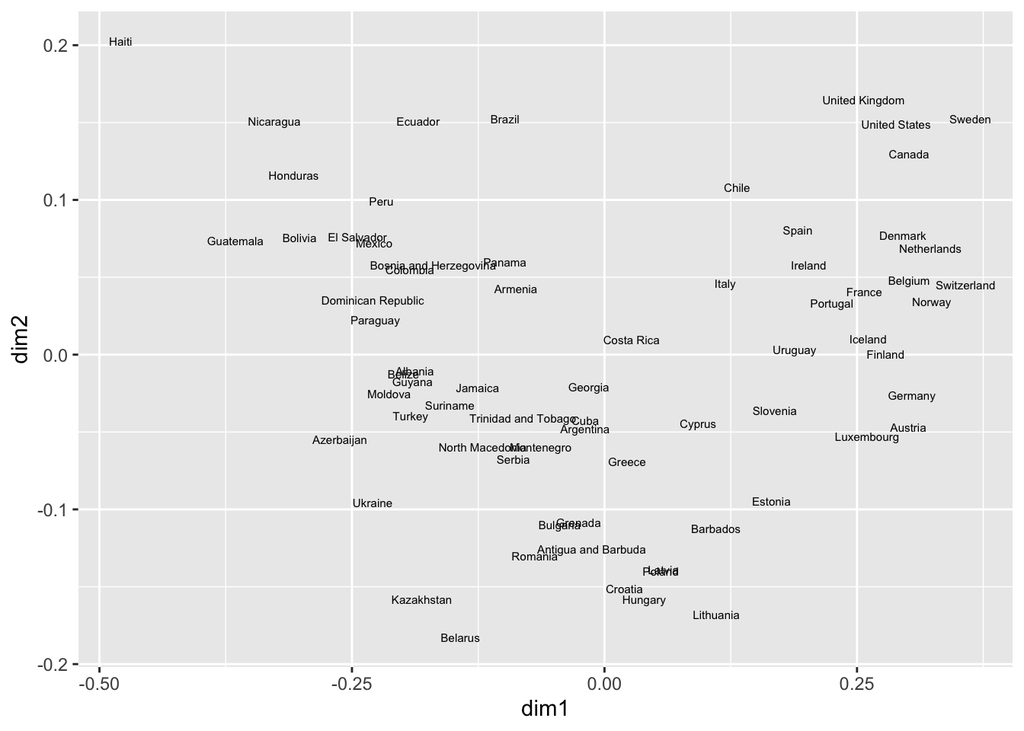

```r
baseCOVID= ggplot(BaseoficialCOVID,aes(x=dim1, y=dim2,label=row.names(BaseoficialCOVID)))
baseCOVID + geom_text(size=2)
```

```r
#calculando los DBSCAN
distancia.cmd= daisy(BaseoficialCOVID[,c('dim1','dim2')], metric = 'euclidean')
```

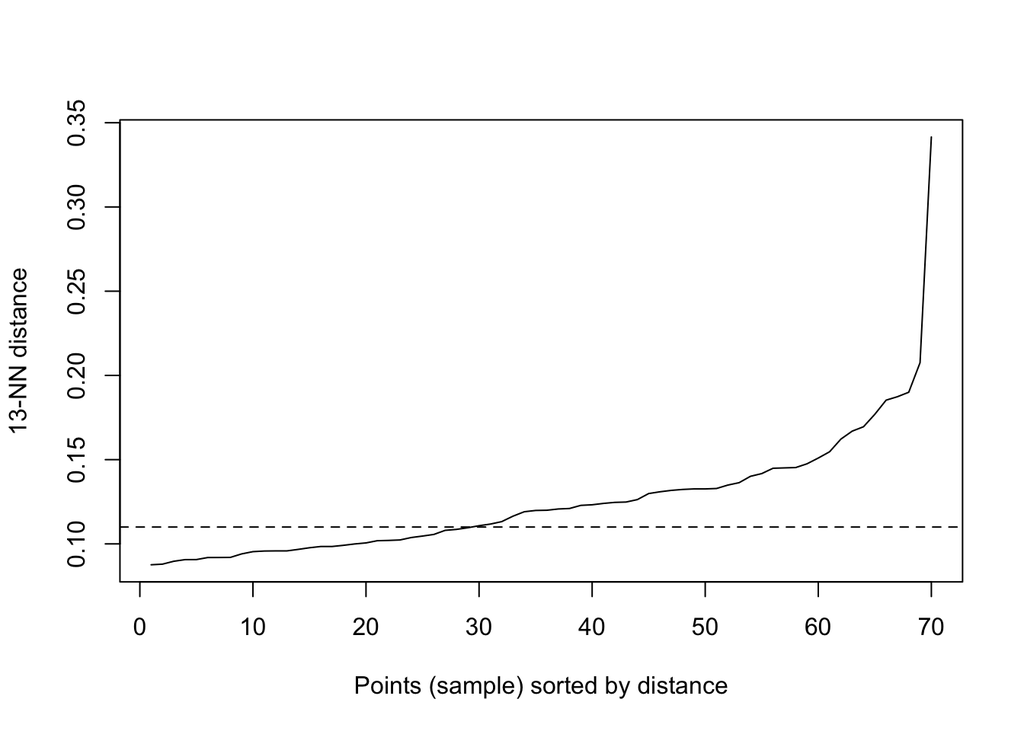

```r
#Calculo de epsilon
library(dbscan)
kNNdistplot(distancia.cmd, k=13)

abline(h=0.11, lty=2)
```

```r
library(fpc)
db.cmd = dbscan(distancia.cmd, eps=0.10, MinPts=13,method = 'dist')

##OJO: ¿cual eps es mejor 0,10 - 0,11
```

```r
BaseoficialCOVID$dbCMD=as.factor(db.cmd$cluster)
```

```r
min(BaseoficialCOVID[,c('dim1','dim2')]); max(BaseoficialCOVID[,c('dim1','dim2')])
```

```
## [1] -0.4789438
```

```
## [1] 0.3622379
```

```r
limites = c(-0.5,0.4)
```

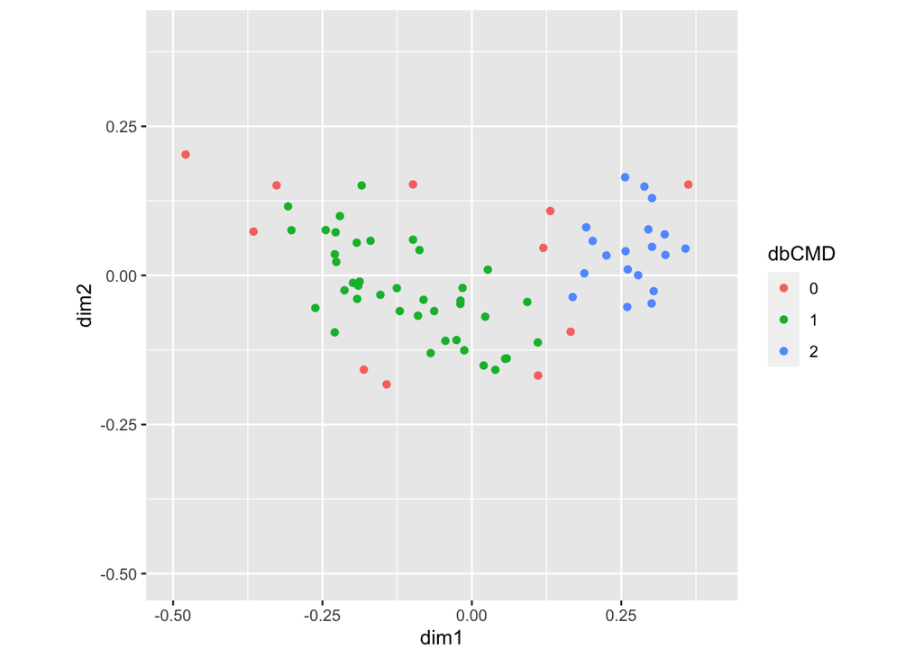

```r
library(ggrepel)
baseCOVID= ggplot(BaseoficialCOVID,aes(x=dim1, y=dim2)) + ylim(limites) + xlim(limites) + coord_fixed()
dbplot_COVID= baseCOVID + geom_point(aes(color=dbCMD))
dbplot_COVID
```

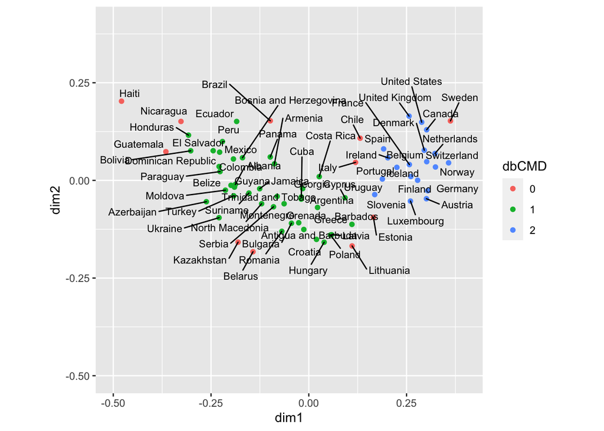

```r
dbplot_COVID + geom_text_repel(size=3,aes(label=row.names(BaseoficialCOVID)))
```

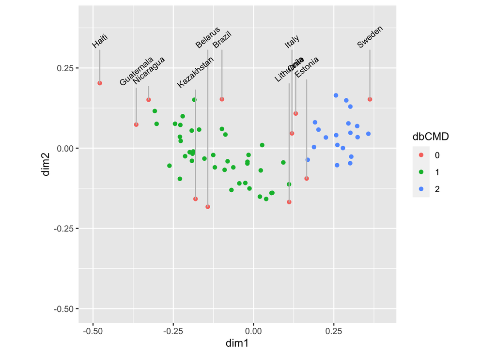

```r
#Aquí sólo los atípicos:
LABEL=ifelse(BaseoficialCOVID$dbCMD==0,row.names(BaseoficialCOVID),"")
dbplot_COVID + geom_text_repel(aes(label=LABEL),
                         size=3,
                         direction = "y", ylim = 0.30,
                         angle=40,
                         segment.colour = "grey")
```